# DATA607NobelJsonCode

Samantha Mesa

2026-11-04

## The four questions:

1. **Gender over time:** How has the share of female laureates changed by decade and by category?
2. **Brain drain (join/compare):** Which countries “lost” the most laureates, meaning laureates born there but awarded while affiliated with an institution in another country, and what is each country’s net gain or loss?
3. **Age at award:** How old are laureates when they win, how does that differ by category, and has it changed over time?
4. **Institutions:** Which institutions are affiliated with the most laureates, and in which fields?

## Approach Potential Challenges

I get each laureate from the paginated `/laureates` endpoint (cycling through `offset` and `limit` until I get the total in `meta$count`) and interpret the response with `jsonlite`, but keep it as a nested list. Then I walk the nesting in `purrr` and create three tidy tables at different grains: one row per laureate, one row per laureate-prize, and one row per laureate-prize-affiliation. These tables are filtered, grouped, or joined on `laureate_id` to answer each question. The raw JSON is cached locally so the document renders quickly and does not hit the API repeatedly.

## Potential Challenges

The main problem is the nesting: a laureate can win more than once, and a prize can have multiple affiliations, so flattening naively either loses data or duplicates rows. Also, the fields are inconsistent across records: organizations don’t have gender or birth data, some older laureates have no affiliation, and some dates are incomplete, so I use a safe accessor that returns `NA` instead of erroring and filter out missing values per question. Place names change over time (a birthplace may have been in a country that no longer exists), so I compare the `countryNow` fields and not the historical names. Finally, institution names aren’t standardized (different campuses or renamed institutes count separately), and the API is paginated and rate-friendly, so I add a short pause between requests and cache results.

```r
library(tidyverse)
library(jsonlite)
library(knitr)

# Safe accessor: returns NA instead of erroring when a nested field is missing
g <- function(x, ...) pluck(x, ..., .default = NA_character_)
```

## Retrieving the JSON

The API is paginated (`offset` and `limit`), and the `meta$count` field in the response tells us the total number of laureates. I loop over the pages and cache the raw result locally so re-rendering does not hit the API every time.

```r
base_url   <- "https://api.nobelprize.org/2.1/laureates"
page_size  <- 100
cache_file <- "nobel_laureates_raw.rds"

if (file.exists(cache_file)) {
  laureates <- readRDS(cache_file)
} else {
  # First request just to learn the total number of laureates
  first <- fromJSON(sprintf("%s?offset=0&limit=%d", base_url, page_size),
                    simplifyVector = FALSE)
  total   <- as.integer(first$meta$count)
  offsets <- seq(0, total - 1, by = page_size)

  pages <- map(offsets, function(o) {
    Sys.sleep(0.3)  # be polite to the API
    fromJSON(sprintf("%s?offset=%d&limit=%d", base_url, o, page_size),
             simplifyVector = FALSE)$laureates
  })

  laureates <- list_flatten(pages)
  saveRDS(laureates, cache_file)
}

length(laureates)
```

```
## [1] 1028
```

## Tidying the JSON into data frames

I build three tidy tables from the nested list:

- `laureates_tbl`: one row per laureate (person or organization)
- `prizes_tbl`: one row per laureate per prize (some people won twice)
- `affil_tbl`: one row per laureate per prize per affiliation

```r
# 1. One row per laureate
laureates_tbl <- map_dfr(laureates, function(l) tibble(
  laureate_id       = g(l, "id"),
  name              = coalesce(g(l, "knownName", "en"), g(l, "orgName", "en")),
  type              = if (!is.null(l$orgName)) "organization" else "person",
  gender            = g(l, "gender"),
  birth_date        = g(l, "birth", "date"),
  birth_country     = g(l, "birth", "place", "country", "en"),
  birth_country_now = g(l, "birth", "place", "countryNow", "en")
))

# 2. One row per laureate-prize
prizes_tbl <- map_dfr(laureates, function(l) {
  map_dfr(l$nobelPrizes %||% list(), function(p) tibble(
    laureate_id = g(l, "id"),
    award_year  = as.integer(g(p, "awardYear")),
    category    = g(p, "category", "en"),
    portion     = g(p, "portion")
  ))
})

# 3. One row per laureate-prize-affiliation
affil_tbl <- map_dfr(laureates, function(l) {
  map_dfr(l$nobelPrizes %||% list(), function(p) {
    map_dfr(p$affiliations %||% list(), function(a) tibble(
      laureate_id       = g(l, "id"),
      award_year        = as.integer(g(p, "awardYear")),
      category          = g(p, "category", "en"),
      institution       = coalesce(g(a, "nameNow", "en"), g(a, "name", "en")),
      affil_country     = g(a, "country", "en"),
      affil_country_now = g(a, "countryNow", "en")
    ))
  })
})

# Sanity checks on the tidy tables
tibble(table = c("laureates_tbl", "prizes_tbl", "affil_tbl"),
       rows  = c(nrow(laureates_tbl), nrow(prizes_tbl), nrow(affil_tbl))) |>
  kable()
```

| table | rows |
| --- | --- |
| laureates_tbl | 1028 |
| prizes_tbl | 1036 |
| affil_tbl | 856 |

```r
glimpse(laureates_tbl)
```

```
## Rows: 1,028
## Columns: 7
## $ laureate_id       <chr> "745", "102", "779", "259", "1004", "114", "982", "9…
## $ name              <chr> "A. Michael Spence", "Aage N. Bohr", "Aaron Ciechano…
## $ type              <chr> "person", "person", "person", "person", "person", "p…
## $ gender            <chr> "male", "male", "male", "male", "male", "male", "mal…
## $ birth_date        <chr> "1943-11-07", "1922-06-19", "1947-10-01", "1926-08-1…
## $ birth_country     <chr> "USA", "Denmark", "British Protectorate of Palestine…
## $ birth_country_now <chr> "USA", "Denmark", "Israel", "Lithuania", NA, "Pakist…
```

```r
glimpse(prizes_tbl)
```

```
## Rows: 1,036
## Columns: 4
## $ laureate_id <chr> "745", "102", "779", "259", "1004", "114", "982", "981", "…
## $ award_year  <int> 2001, 1975, 2004, 1982, 2021, 1979, 2019, 2019, 2009, 2011…
## $ category    <chr> "Economic Sciences", "Physics", "Chemistry", "Chemistry", …
## $ portion     <chr> "1/3", "1/3", "1/3", "1", "1", "1/3", "1/3", "1", "1/3", "…
```

```r
glimpse(affil_tbl)
```

```
## Rows: 856
## Columns: 6
## $ laureate_id       <chr> "745", "102", "779", "259", "114", "114", "982", "84…
## $ award_year        <int> 2001, 1975, 2004, 1982, 1979, 1979, 2019, 2009, 2011…
## $ category          <chr> "Economic Sciences", "Physics", "Chemistry", "Chemis…
## $ institution       <chr> "Stanford University", "Niels Bohr Institute", "Tech…
## $ affil_country     <chr> "USA", "Denmark", "Israel", "United Kingdom", "Italy…
## $ affil_country_now <chr> "USA", "Denmark", "Israel", "United Kingdom", "Italy…
```

Organizations (for example, the Red Cross) have no gender or birth data, so questions about people use only rows where `type == "person"`.

```r
people <- laureates_tbl |> filter(type == "person")
```

## Question 1: How has the share of female laureates changed over time?

**Description.** Women are a small minority of laureates historically. I join prizes to laureate gender, compute the share of female laureates per decade, and then per category.

```r
person_prizes <- prizes_tbl |>
  inner_join(people, by = "laureate_id") |>
  filter(!is.na(gender))

by_decade <- person_prizes |>
  mutate(decade = award_year %/% 10 * 10) |>
  group_by(decade) |>
  summarise(prizes = n(),
            female = sum(gender == "female"),
            pct_female = female / prizes,
            .groups = "drop")

by_category <- person_prizes |>
  group_by(category) |>
  summarise(prizes = n(),
            female = sum(gender == "female"),
            pct_female = female / prizes,
            .groups = "drop") |>
  arrange(desc(pct_female))

by_category |>
  mutate(pct_female = scales::percent(pct_female, accuracy = 0.1)) |>
  kable(caption = "Female share of individual laureates, by category (all years)")
```

Female share of individual laureates, by category (all years)

| category | prizes | female | pct_female |
| --- | --- | --- | --- |
| Peace | 113 | 21 | 18.6% |
| Literature | 123 | 19 | 15.4% |
| Physiology or Medicine | 235 | 14 | 6.0% |
| Chemistry | 202 | 8 | 4.0% |
| Economic Sciences | 101 | 3 | 3.0% |
| Physics | 231 | 5 | 2.2% |

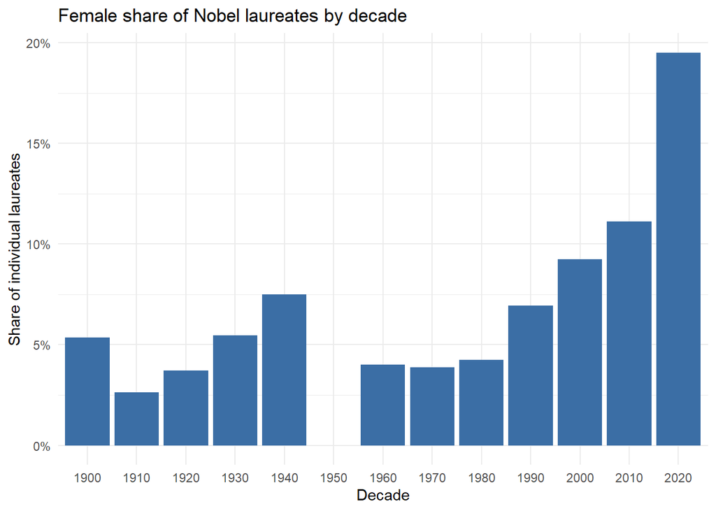

```r
ggplot(by_decade, aes(factor(decade), pct_female)) +
  geom_col(fill = "#3b6ea5") +
  scale_y_continuous(labels = scales::percent) +
  labs(title = "Female share of Nobel laureates by decade",
       x = "Decade", y = "Share of individual laureates") +
  theme_minimal()
```

```r
best_cat <- by_category |> slice(1)
best_dec <- by_decade |> slice_max(pct_female, n = 1, with_ties = FALSE)
```

**Answer.** The category with the highest female share is **Peace** (18.6%), and the decade with the highest female share is the **2020s** (19.5%). The table and plot above show the full picture.

## Question 2: Which countries lost the most laureates (brain drain)?

**Description.** This question requires joining three tables. For each prize won by a person, I compare the laureate’s **birth country** (from `laureates_tbl`) with the **country of their first listed affiliation** at the time of the award (from `affil_tbl`). A laureate “moved” if the two differ. I use the `countryNow` fields for both so that historical names are compared on current borders. Then I compute, per country, how many laureates it lost (born there, affiliated elsewhere), how many it gained (affiliated there, born elsewhere), and the net.

```r
# First listed affiliation per laureate-prize
primary_affil <- affil_tbl |>
  filter(!is.na(affil_country_now)) |>
  group_by(laureate_id, award_year, category) |>
  slice(1) |>
  ungroup()

moves <- prizes_tbl |>
  inner_join(people, by = "laureate_id") |>
  inner_join(primary_affil, by = c("laureate_id", "award_year", "category")) |>
  filter(!is.na(birth_country_now)) |>
  mutate(moved = birth_country_now != affil_country_now)

# Share of laureates who work in a different country than where they were born
moves |> summarise(prizes = n(), moved = sum(moved), pct_moved = moved / prizes) |>
  mutate(pct_moved = scales::percent(pct_moved, accuracy = 0.1)) |>
  kable(caption = "Overall: laureates affiliated outside their birth country")
```

Overall: laureates affiliated outside their birth country

| prizes | moved | pct_moved |
| --- | --- | --- |
| 764 | 245 | 32.1% |

```r
lost <- moves |> filter(moved) |>
  count(country = birth_country_now, name = "lost")
gained <- moves |> filter(moved) |>
  count(country = affil_country_now, name = "gained")
born_total <- moves |>
  count(country = birth_country_now, name = "born_total")

flow <- full_join(lost, gained, by = "country") |>
  left_join(born_total, by = "country") |>
  replace_na(list(lost = 0, gained = 0, born_total = 0)) |>
  mutate(net = gained - lost,
         pct_lost = if_else(born_total > 0, lost / born_total, NA_real_))

flow |>
  arrange(desc(lost)) |>
  slice_head(n = 10) |>
  mutate(pct_lost = scales::percent(pct_lost, accuracy = 0.1)) |>
  kable(caption = "Top 10 countries by laureates lost")
```

Top 10 countries by laureates lost

| country | lost | gained | born_total | net | pct_lost |
| --- | --- | --- | --- | --- | --- |
| Germany | 25 | 25 | 74 | 0 | 33.8% |
| United Kingdom | 24 | 35 | 84 | 11 | 28.6% |
| Poland | 19 | 0 | 19 | -19 | 100.0% |
| Canada | 15 | 6 | 19 | -9 | 78.9% |
| France | 13 | 11 | 43 | -2 | 30.2% |
| Russia | 11 | 3 | 20 | -8 | 55.0% |
| Austria | 10 | 2 | 15 | -8 | 66.7% |
| Scotland | 9 | 0 | 9 | -9 | 100.0% |
| the Netherlands | 9 | 1 | 18 | -8 | 50.0% |
| Hungary | 8 | 0 | 10 | -8 | 80.0% |

```r
moves |>
  filter(moved) |>
  count(from = birth_country_now, to = affil_country_now, sort = TRUE, name = "laureates") |>
  slice_head(n = 10) |>
  kable(caption = "Top 10 migration routes (birth country to affiliation country)")
```

Top 10 migration routes (birth country to affiliation country)

| from | to | laureates |
| --- | --- | --- |
| United Kingdom | USA | 19 |
| Canada | USA | 15 |
| Germany | USA | 12 |
| Poland | Germany | 9 |
| France | USA | 8 |
| Japan | USA | 7 |
| Scotland | United Kingdom | 7 |
| China | USA | 6 |
| Poland | USA | 6 |
| Italy | USA | 5 |

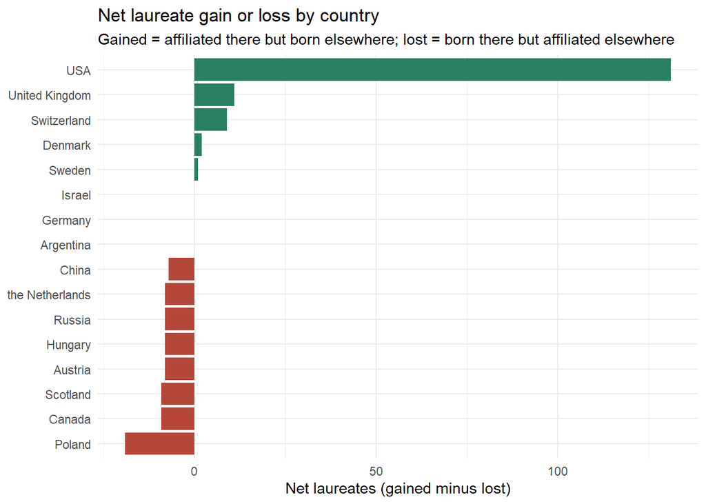

```r
net_plot <- bind_rows(
  slice_max(flow, net, n = 8, with_ties = FALSE),
  slice_min(flow, net, n = 8, with_ties = FALSE)
) |> distinct()

ggplot(net_plot, aes(reorder(country, net), net, fill = net > 0)) +
  geom_col(show.legend = FALSE) +
  scale_fill_manual(values = c("TRUE" = "#2a7f62", "FALSE" = "#b5473a")) +
  coord_flip() +
  labs(title = "Net laureate gain or loss by country",
       subtitle = "Gained = affiliated there but born elsewhere; lost = born there but affiliated elsewhere",
       x = NULL, y = "Net laureates (gained minus lost)") +
  theme_minimal()
```

```r
top_lost <- flow |> arrange(desc(lost)) |> slice(1)
top_net  <- flow |> arrange(desc(net)) |> slice(1)
```

**Answer.** The country that lost the most laureates is **Germany** (25 laureates born there but affiliated elsewhere). The biggest net winner is **USA** (net 131). The route table shows where laureates tend to go.

## Question 3: How old are laureates when they win, and is it changing?

**Description.** I compute age at award as `award_year - birth_year`. I use the birth year only, so ages are approximate to within one year. I compare the distribution by category and look at the trend over time.

```r
ages <- prizes_tbl |>
  inner_join(people, by = "laureate_id") |>
  mutate(birth_year = as.integer(str_sub(birth_date, 1, 4)),
         age = award_year - birth_year) |>
  filter(!is.na(age), age > 0)

ages |>
  group_by(category) |>
  summarise(n = n(),
            median_age = median(age),
            mean_age = round(mean(age), 1),
            youngest = min(age),
            oldest = max(age),
            .groups = "drop") |>
  arrange(median_age) |>
  kable(caption = "Age at award by category")
```

Age at award by category

| category | n | median_age | mean_age | youngest | oldest |
| --- | --- | --- | --- | --- | --- |
| Physics | 231 | 56 | 57.8 | 25 | 96 |
| Chemistry | 202 | 58 | 59.5 | 35 | 97 |
| Physiology or Medicine | 235 | 58 | 59.0 | 32 | 87 |
| Peace | 113 | 62 | 61.0 | 17 | 87 |
| Economic Sciences | 101 | 67 | 67.2 | 47 | 90 |
| Literature | 123 | 67 | 65.0 | 42 | 88 |

```r
bind_rows(
  ages |> slice_min(age, n = 3, with_ties = FALSE) |> mutate(which = "youngest"),
  ages |> slice_max(age, n = 3, with_ties = FALSE) |> mutate(which = "oldest")
) |>
  select(which, name, category, award_year, age) |>
  kable(caption = "Youngest and oldest recipients")
```

Youngest and oldest recipients

| which | name | category | award_year | age |
| --- | --- | --- | --- | --- |
| youngest | Malala Yousafzai | Peace | 2014 | 17 |
| youngest | Lawrence Bragg | Physics | 1915 | 25 |
| youngest | Nadia Murad | Peace | 2018 | 25 |
| oldest | John B. Goodenough | Chemistry | 2019 | 97 |
| oldest | Arthur Ashkin | Physics | 2018 | 96 |
| oldest | Henri B. Kagan | Chemistry | 2026 | 96 |

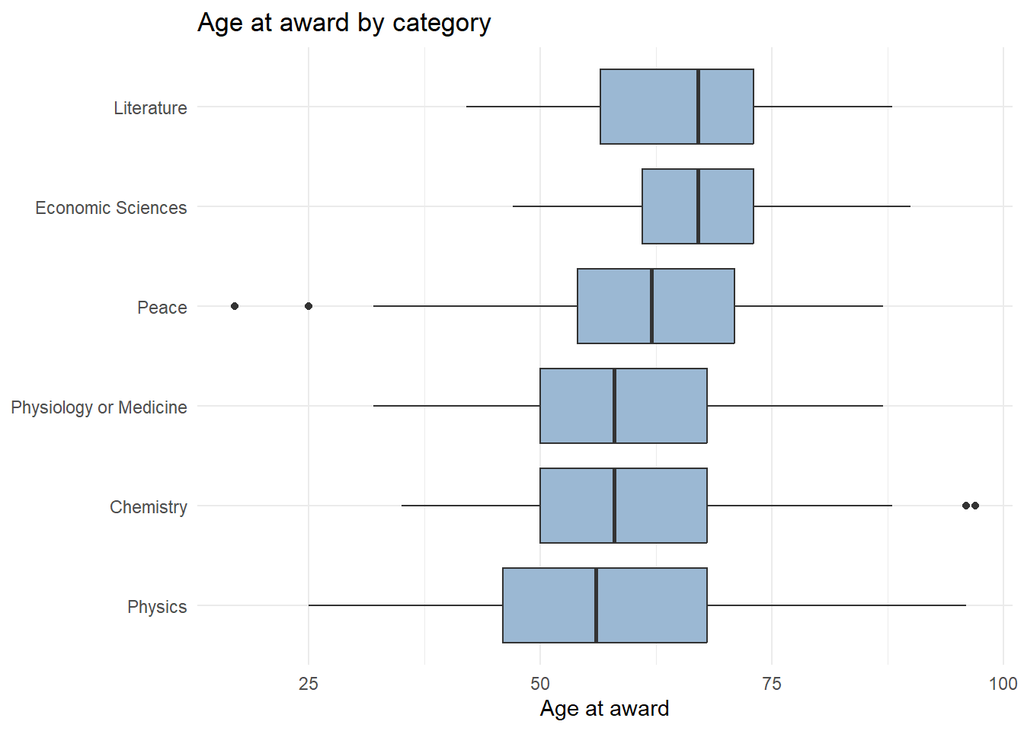

```r
ggplot(ages, aes(reorder(category, age, median), age)) +
  geom_boxplot(fill = "#9bb8d3") +
  coord_flip() +
  labs(title = "Age at award by category", x = NULL, y = "Age at award") +
  theme_minimal()
```

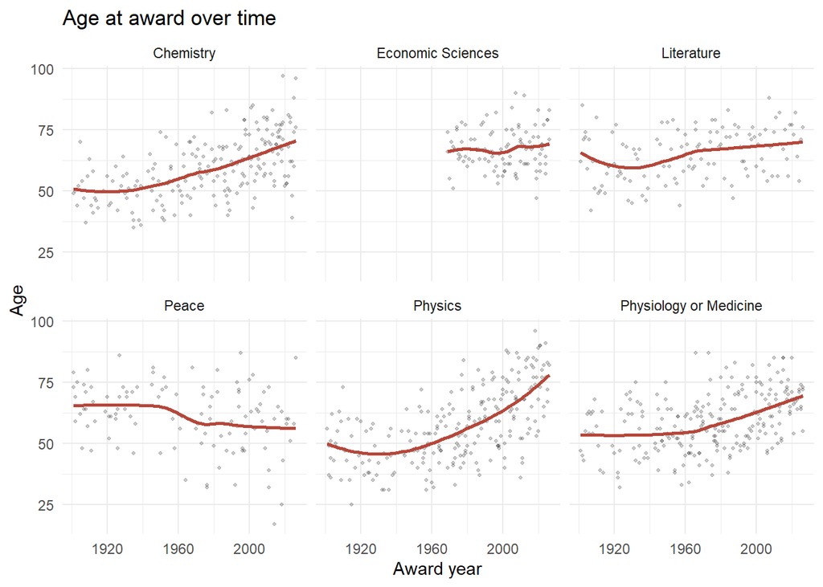

```r
ggplot(ages, aes(award_year, age)) +
  geom_point(alpha = 0.2, size = 0.8) +
  geom_smooth(method = "loess", se = FALSE, color = "#b5473a") +
  facet_wrap(~ category) +
  labs(title = "Age at award over time", x = "Award year", y = "Age") +
  theme_minimal()
```

```r
youngest_cat <- ages |> group_by(category) |> summarise(m = median(age)) |> slice_min(m, n = 1, with_ties = FALSE)
oldest_cat   <- ages |> group_by(category) |> summarise(m = median(age)) |> slice_max(m, n = 1, with_ties = FALSE)
```

**Answer.** The category with the youngest median winner is **Physics** (median 56), and the oldest is **Economic Sciences** (median 67). The faceted trend plot shows whether the age at award has been rising in each field.

## Question 4: Which institutions are linked to the most laureates?

**Description.** Using the affiliation table, I count distinct laureate-prize pairs per institution (so a laureate is not double counted if an institution is listed twice for the same prize). I use `nameNow` (the institution’s current name) where available, falling back to the name at the time. Then I break the top institutions down by prize category.

```r
inst_counts <- affil_tbl |>
  filter(!is.na(institution)) |>
  distinct(laureate_id, award_year, category, institution) |>
  count(institution, name = "laureates", sort = TRUE)

top_inst <- inst_counts |> slice_head(n = 10)
kable(top_inst, caption = "Top 10 institutions by number of laureate affiliations")
```

Top 10 institutions by number of laureate affiliations

| institution | laureates |
| --- | --- |
| University of California | 43 |
| Harvard University | 29 |
| Massachusetts Institute of Technology (MIT) | 25 |
| Stanford University | 24 |
| California Institute of Technology (Caltech) | 20 |
| University of Chicago | 20 |
| Columbia University | 19 |
| Princeton University | 18 |
| University of Cambridge | 18 |
| Howard Hughes Medical Institute | 17 |

```r
inst_by_cat <- affil_tbl |>
  filter(institution %in% top_inst$institution) |>
  distinct(laureate_id, award_year, category, institution) |>
  count(institution, category, name = "laureates")
```

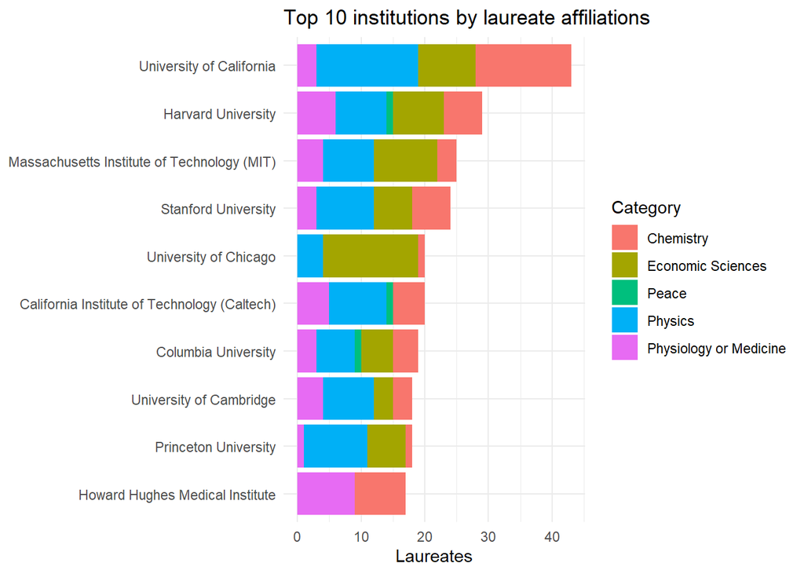

```r
ggplot(inst_by_cat, aes(reorder(institution, laureates, sum), laureates, fill = category)) +
  geom_col() +
  coord_flip() +
  labs(title = "Top 10 institutions by laureate affiliations",
       x = NULL, y = "Laureates", fill = "Category") +
  theme_minimal()
```

```r
top1 <- top_inst |> slice(1)
```

**Answer.** The institution with the most laureate affiliations is **University of California** with **43** laureates. The stacked bars show which fields each top institution is strongest in.

*Caveat:* institution names are used as the API gives them, so different campuses or institutes of the same organization (for example, separate University of California campuses) count as separate institutions.

## Conclusion

Nested JSON from the Nobel Prize API can be flattened into tidy tables with `jsonlite` and `purrr`, and the interesting questions come from joining those tables, here birth place from the laureate record against affiliation country from the prize record.

*Data source: Nobel Prize API v2.1, NobelPrize.org (Nobel Prize Outreach).*